# NLP_Intro

Ivan Krukov

July 29, 2015

# Previous material

Here is a list of the material previously covered:

- Introduction
- Linear regression
- Logistic regression theory
- Logistic regression
- Decision trees
- Back to fundamentals
- [Sample data analysis in python](http://nbviewer.ipython.org/urls/gist.githubusercontent.com/anonymous/559791fe88b87689e295/raw/f23f1c8bf7b3f23732722696cf2c7ffc6327d649/sample-kaggle.ipynb)
- Caret tutorial

# NLP introduction

This a brief introduction to the natural language data analysis in `R`. We will look at data preparation, stop words, stemming and finally a little bit of learning.

The data we will be looking at are IMDB movie reviews, and we will use supervised techniques to determine if a review is positive or not.

The example shows some of the common features of the [bag-of-words](https://en.wikipedia.org/wiki/Bag-of-words_model) approach. It is a regression method that classifies a body of text based on word frequencies.

In general, we want to prepare a matrix of term counts. Each row corresponds to an observation (a single comment, in our case), and each column corresponds to a particular word. Each entry encodes the frequency of a word within a comment. Here, we do not consider the structure of language, but only the sentiments that each word carries.

Once the data is prepared, we can use any learning algorithm to determine the sentiment of the comment.

We will mostly focus on the `tm` (*T*ext *M*ining) package.

# Data

The data is taken from an excellent [Kaggle bag of words tutorial](https://www.kaggle.com/c/word2vec-nlp-tutorial). The tutorial showcases Google’s [Word2Vec](https://code.google.com/p/word2vec/) framework.

- IMDB ratings

# The process

## Data reading

Let’s read the data first. Here we have the `tsv` (tab-separated value) format, which we can read with the `read.delim` function. We can also use `read.table` with `sep='\t'`, which is the same thing. Check out `?read.table`, if you are interested. All the `read.*` functions call `read.table` with different default parameters.

Another thing we have to worry about is the fact that `R` tries to use strings as factor variables by default. To prevent that, pass `stringsAsFactors=FALSE`.

Also, the data has all the quote (“) characters escaped. This will make `read.delim` rather confused, so we can override the default behaviour by changing `quote` to an empty string: `quote=""`.

```r
movieReviews <- read.delim("data/NLPLabeledTrainData.tsv", stringsAsFactors = F, quote="")
str(movieReviews)
```

```
## 'data.frame':    25000 obs. of  3 variables:
##  $ id       : chr  "\"5814_8\"" "\"2381_9\"" "\"7759_3\"" "\"3630_4\"" ...
##  $ sentiment: int  1 1 0 0 1 1 0 0 0 1 ...
##  $ review   : chr  "\"With all this stuff going down at the moment with MJ i've started listening to his music, watching the odd documentary here a"| __truncated__ "\"\\\"The Classic War of the Worlds\\\" by Timothy Hines is a very entertaining film that obviously goes to great effort and le"| __…
```

```r
table(movieReviews$sentiment)
```

```
##
##     0     1
## 12500 12500
```

`Sentiment` is a binary variable, encoded as `1` for “positive” and `0` for negative.

## Packages

The bulk of the text processing is done with the `tm` package. For this tutorial, I will use the CART classifier from `rpart`. We can use any other supervised approach, which I encourage you to do.

```r
install.packages(c("tm", "rpart", "rpart.plot", "caTools"))
```

```r
library(tm)
```

```r
library(rpart)
library(rpart.plot)
library(caTools)
```

## Working with text

In Natural Language Processing jargon, “a body of text” is called “corpus”, literally “body” in Latin.

Let’s create our corpus using `tm`:

```r
corpus <- Corpus(VectorSource(movieReviews$review))
```

The variable `corpus` is a large list, each entry being a list which represents a single comment. The text itself is stored in `content`, for example `corpus[[1]]$content`. The other fields are meta-data, such as language, author, date, etc. Here, we are only concerned with `content`. Each comment is of `PlainTextDocument` type.

What we are after is a representation of the comments that is somehow normalized. Following are some of the common steps:

### Case normalization

The first thing we want to do is to change all the words in lowercase. `tm` has a `tm_map` function. This function applies another function (which you provide) to each `content` of the `corpus`. Such function mapping is a common idiom in `R`.

`R` itself ships with `tolower` function that converts a given string to lower case. Let’s map it to the corpus with `tm_map`. To make sure the returned strings are put in the right place, we use the `content_transformer` function:

```r
corpus <- tm_map(corpus, content_transformer(tolower))
```

### Punctuation

The next thing we do is drop all the punctuation marks. For word frequencies, counts of commas and full stops should not matter, and is hard to interpret.

```r
corpus <- tm_map(corpus, removePunctuation)
```

### Numbers

The other thing that we would like to get rid of are numbers. We want to filter out all the words like “101st”, “3-year-old”, and so on. We now take a necessary (but small) digression into regular expressions.

#### Regular expressions

For our purposes, a regular expression is a pattern that can match some text. In this case, we want to match all the text that contains numbers. Practially, there are two types of “things” inside regular expressions - characters (or character classes) and repeat characters.

Characters are just that - a single symbol. For example ‘x’ matches “x”, ‘z’ matches “z”. We can use functions like `grep` to search for characters in vectors:

```r
grep("Z",c("Zebra","Lion","Zoo"))
```

```
## [1] 1 3
```

We get `c(1, 3)`, saying that ‘Z’ was found in first and third entries.

Character class is a definition that matches a particular type of characters. For example, `[:blank:]` matches all the “blank”-type characters, `[:alpha:]` corresponds to alphabet characters, `[:digit:]` corresponds to digits. An important class is `.` (a single dot). The dot matches any character.

We can put characters together by writing them in sequence. So `hello` matches ‘h’ followed by ‘e’, followed by ‘l’, … you get the idea.

We can combine characters inside square brackets `[]`. This allows us to make `or`-type associations. So if we want to match numbers or letter ‘E’, we could use `[[:digit:]E]`.

Repeat characters are rather simple. `*` means “zero or more times”, `+` means “at least once”.

This leads to a common idiom - the “catch-all”. `.*` will match any character any number of times, even zero. The issue with the “catch-all” is that it’s greedy. This means that if we try to mix it with other regular expressions, they will be simply ignored. We need the non-greedy version of it, which looks like `.*?`. This non-greedy catch-all still matches anything, but it is polite, and gives way to other expressions.

`R` has the `gsub` function which takes a pattern and replaces it with a string: `gsub(pattern, replcement, x)`. We can use that with our newly minted regular expression to filter out all things that contain numbers:

```r
corpus <- tm_map(corpus, content_transformer( function(x){gsub(".*?[[:digit:]]+.*?", "", x)}) )
```

Regular expressions are a hard concept, but are extremely useful. Still, they are confusing and cryptic, so should be used with great care. There are alternative solutions, but this is the first that I could think of.

### Stop words

Stop words are parts of speech that cary little semantic meaning. Examples are articles (‘a’, ‘the’), prepositions (‘of’, ‘as’), pronouns (‘it’, ‘mine’), and conjunctions (‘or’, ‘yet’). In essense, we only want the words that mean something alone.

The `tm` package has a `stopwords` function, which returns a vector of stopwords for a given language. English is default, but there is also support of other languages. See `?stopwords`.

```r
corpus <- tm_map(corpus, removeWords, stopwords())
```

### Stemming

The last step is stemming. We want to make words like “stemming”, “stemmed”, “stems” all equivalent. One way to do this is remove the suffixes, leaving only “stem”.

```r
corpus <- tm_map(corpus, stemDocument)
```

Let’s see what our normalization steps have achived:

```r
corpus[[1]]$content
```

```
## [1] " minut   exclud  smooth crimin sequenc  joe pesci  convinc   psychopath  power drug lord   want mj dead  bad  beyond   mj overheard  plan nah joe pesci charact rant   want peopl  know      suppli drug etc   dunno mayb  just hate mjs musicbr br lot  cool thing   like mj turn   car   robot   w…
```

## Matrix building

Let’s make a matrix of word frequencies from our corpus:

```r
wordFrequencies <- DocumentTermMatrix(corpus)
inspect(wordFrequencies[100:110,100:110])
```

```
## <<DocumentTermMatrix (documents: 11, terms: 11)>>
## Non-/sparse entries: 0/121
## Sparsity           : 100%
## Maximal term length: 13
## Weighting          : term frequency (tf)
##
##      Terms
## Docs  abandon abandonbr abandoningbr abandonmentbr abash abashidz abat
##   100       0         0            0             0     0        0    0
##   101       0         0            0             0     0        0    0
##   102       0         0            0             0     0        0    0
##   103       0         0            0             0     0        0    0
##   104       0         0            0             0     0        0    0
##   105       0         0            0             0     0        0    0
##   106       0         0            0             0     0        0    0
##   107       0         0            0             0     0        0    0
##   108       0         0            0             0     0        0    0
##   109       0         0            0             0     0        0    0
##   110       0         0            0             0     0        0    0
##      Terms
## Docs  abattoir abba abbad abbasmustan
##   100        0    0     0           0
##   101        0    0     0           0
##   102        0    0     0           0
##   103        0    0     0           0
##   104        0    0     0           0
##   105        0    0     0           0
##   106        0    0     0           0
##   107        0    0     0           0
##   108        0    0     0           0
##   109        0    0     0           0
##   110        0    0     0           0
```

One of the issues we can see right away is that the matrix is really sparse. The other is that some of the words do not exactly make sense. There is a lot of room for improvement by advanced language models.

We can now remove the uncommon words by using `removeSparseTerms`. The argument passed to this function is “sparsity coefficient”. For example `removeSparseTerms(wordFrequencies, 0.995)` will remove any columns that are 99.5% sparse, or, in other words, have counts in less than half a percent of the corpus.

```r
sparse <- removeSparseTerms(wordFrequencies, 0.999)
wordData <- as.data.frame(as.matrix(sparse))
```

Let’s make the column names a little more informative, and add our sentiment column:

```r
colnames(wordData) <- make.names(colnames(wordData))
wordData$sentiment <- as.factor(movieReviews$sentiment)
```

# Learning

Now let’s do the actual learning. Let’s use `caTools` for the train-test split.

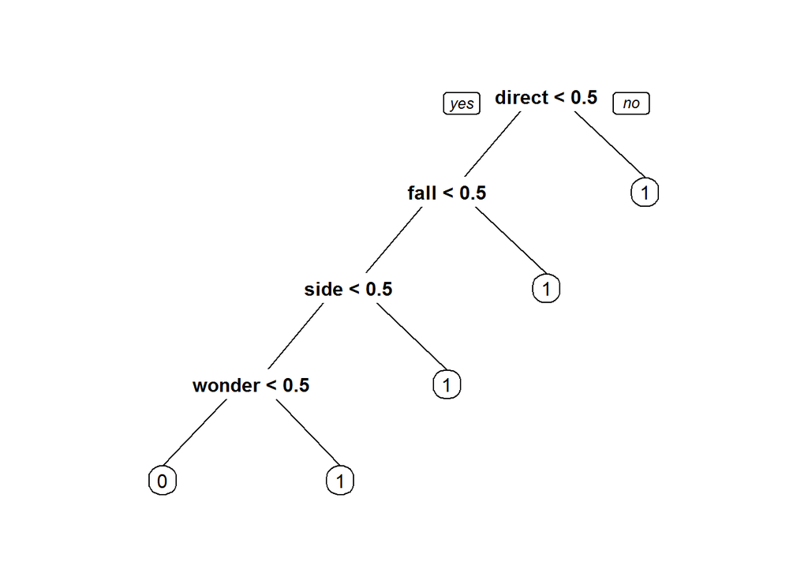

```r
library(caTools)

# Split-off 70% of the data
split = sample.split(wordData$sentiment, SplitRatio = 0.7)
train = subset(wordData, split==TRUE)
test = subset(wordData, split==FALSE)

# Modeling and plotting
imdbCART <- rpart(sentiment ~ ., data = train, method = "class")
rpart.plot(imdbCART)
```

```r
#Accuracy estimate
prediction <- predict(imdbCART, test, type = "class")
confusionMatrix <- table(prediction, test$sentiment)
confusionMatrix
```

[output not shown]

```r
accuracy <- sum(diag(confusionMatrix))/sum(confusionMatrix)
accuracy
```

[output not shown]

Given the dissapointing result, we can try a random forest to predict the sentiment:

```r
imbdRF <- randomForest(sentiment ~ ., data = train, method = "class")

prediction <- predict(imdbRF, test, type = "class")
confusionMatrix <- table(prediction, test$sentiment)

accuracy <- sum(diag(confusionMatrix))/sum(confusionMatrix)
```

This should produce better results, hopefully.